# UADE - Maestria TIC - Ciencia de Datos - Modelo de predicción para aprobación de Tarjetas de Crédito

Marcelo Capozzi (LU: 1119183) - Nicolas Gladkoff (LU: 1085075)

Abril 2020

#### GitHub:

https://github.com/ngladkoff/ds-credit-card-approval

#### DataSource:

https://www.kaggle.com/rikdifos/credit-card-approval-prediction

# Introducción

La salud de la industria de tarjetas de crédito se mide no por el número de personas con tarjeta, sino por el número de personas que pagan sus consumos.

La empresa que nos contrata actualmente toma la decisión respecto a si aprueba o no un crédito basándose en informes comerciales sobre el historial crediticio de la persona solicitante.

En los casos en que la persona no tenga historial crediticio, o que el historial crediticio sea bueno, el crédito se otorga.

Se busca brindar a la empresa una herramienta adicional que mejore la selección en los casos que no se cuente con información crediticia histórica.

# Objetivo

El presente trabajo busca evaluar si es posible predecir, en base a los datos de una solicitud de tarjeta de crédito, si el crédito tiene una alta probabilidad de quedar impago (créditos malos).

Para entrenar este modelo de predicción se analizarán los datos de la información histórica y del comportamiento de pago de los clientes pasados y actuales de la entidad.

Considerando que este modelo va a utilizarse solamente para aquellas solicitudes que no cuenten con información crediticia previa, el negocio establece como suficiente que detecte 2 de cada 3 créditos malos. Además, se busca que sea capaz de detectar al menos 3 de cada 4 créditos buenos.

# Datos

La entidad crediticia nos proporcionó los datos históricos que tienen disponibles, datos que deberán ser analizados para evaluar su calidad y si son suficientes para ayudarnos a resolver el problema.

Se nos proporcionó 2 datasets:

- application_record.csv: que contiene los datos de las solicitudes de tarjetas de crédito
- credit_record.csv: que contiene la información histórica del comportamiento de pagos

En pos de cumplir la meta propuesta, al set de datos proporcionado vamos a agregarle una variable Objetivo *Approve*. Esta variable se completará analizando el historial crediticio que tuvieron las solicitudes, y tendrá dos valores posibles:

| Valor | Descripción |
| --- | --- |
| 1 | Representa un crédito bueno, que debería ser aprobado |
| 0 | Representa un crédito malo, que no debería ser aprobado |

## Diccionario de datos

Descripción de los datasets

*application_record*

| Nombre | Descripción | Observaciones |
| --- | --- | --- |
| ID | Número de Cliente |  |
| CODE_GENDER | Género |  |
| FLAG_OWN_CAR | Posee automóvil propio? |  |
| FLAG_OWN_REALTY | Es propietario? |  |
| CNT_CHILDREN | Cantidad de Hijos |  |
| AMT_INCOME_TOTAL | Ingreso Anual (u$d) |  |
| NAME_INCOME_TYPE | Tipo de Ingreso |  |
| NAME_EDUCATION_TYPE | Nivel Educativo |  |
| NAME_FAMILY_STATUS | Estado Civil |  |
| NAME_HOUSING_TYPE | Tipo de Vivienda |  |
| DAYS_BIRTH | Días desde la fecha de nacimiento |  |
| DAYS_EMPLOYED | Días desde la fecha de inicio laboral |  |
| FLAG_MOBIL | Tiene Celular? |  |
| FLAG_WORK_PHONE | Dejó Teléfono Laboral? |  |
| FLAG_PHONE | Dejó Teléfono Particular? |  |
| FLAG_EMAIL | Dejó su Email? |  |
| OCCUPATION_TYPE | Actividad Laboral |  |
| CNT_FAM_MEMBERS | Cantidad Integrantes de la familia |  |

*credit_record*

| Nombre | Descripción | Observaciones |
| --- | --- | --- |
| ID | Número de Cliente |  |
| MONTHS_BALANCE | Mes del registro | El mes al que pertenece el registro es contado hacia atrás, 0 es el mes actual, -1 el anterior y así sucesivamente. |
| STATUS | Estado | *Ver tabla STATUS* |

*STATUS*

| STATUS | Descripción |
| --- | --- |
| 0 | 1-29 días deudor |
| 1 | 30-59 días deudor |
| 2 | 60-89 días deudor |
| 3 | 90-119 días deudor |
| 4 | 120-149 días deudor |
| 5 | más de 150 días deudor |
| C | canceló las deudas ese mes |
| X | sin deudas ese mes |

*Variables generadas al procesar los datos*

| Nombre | Descripción | Observaciones |
| --- | --- | --- |
| AGE | Edad |  |
| YEARS_EMPLOYED | Años en el empleo |  |
| Approved | (Objetivo) El crédito debe o no ser aprobado |  |

## Configuración de ambiente y carga de los datos

Configuramos las librerías a utilizar y cargamos los datasets en el ambiente de trabajo.

```r
##################
# Load libraries #
##################
library(ggplot2)
library(dplyr)
library(sqldf)
library(corrplot)
library(rms)
library(Information)
library(grid)
library(ROCR)
library(DMwR)
```

Si los datasets no están en el directorio de trabajo los descargamos:

```r
######################
# Download datafiles #
######################

# Set the data directory
# It will be a subdirectory 'data/' of the current directory
maindir <- getwd()
datadir <- paste(maindir, "data", sep="/")

applRecordURL <- "https://raw.githubusercontent.com/ngladkoff/ds-credit-card-approval/master/data/application_record.csv"
credRecordURL <- "https://raw.githubusercontent.com/ngladkoff/ds-credit-card-approval/master/data/credit_record.csv"

applRecordFile <- paste(datadir, "applRecord.csv", sep="/")
credRecordFile <- paste(datadir, "credRecord.csv", sep="/")

if (!dir.exists(datadir)) {
    print(paste("Creating data directory ", datadir))
    dir.create(datadir)
}

if (!file.exists(applRecordFile)) {
    print("Downloading Application Records")
    download.file(applRecordURL, applRecordFile, method="auto")
} else {
    print(paste("Data file", applRecordFile, "already exists"))
}
```

```
## [1] "Data file C:/dev/ds-credit-card-approval/src/CCA/data/applRecord.csv already exists"
```

```r
if (!file.exists(credRecordFile)) {
    print("Downloading Application Records")
    download.file(credRecordURL, credRecordFile, method="auto")
} else {
    print(paste("Data file", credRecordFile, "already exists"))
}
```

```
## [1] "Data file C:/dev/ds-credit-card-approval/src/CCA/data/credRecord.csv already exists"
```

```r
#######################
# Load the dataframes #
#######################

dfApplications <- read.csv(applRecordFile)
dfCredits <- read.csv(credRecordFile)
```

Definimos una función que vamos a necesitar mas adelante

```r
nplot <- function(plist) {
  n <- length(plist)
  grid.newpage()
  pushViewport(viewport(layout=grid.layout(n,1)))
  vplayout=function(x,y) { viewport(layout.pos.row=x, layout.pos.col=y) }
  for (i in 1:n) {
    print(plist[[i]], vp=vplayout(i,1))
  }
}
```

Definimos una semilla por si usamos generadores de datos aleatoreos, para garantizar reproducibilidad.

```r
set.seed(1234)
```

# Análisis Exploratorio de Datos

## 1 - Exámen inicial de los datos

### 1.1 - Dataset: Applications

#### 1.1.1 - Estructura

```r
str(dfApplications)
```

```
## 'data.frame':    438557 obs. of  18 variables:
##  $ ID                 : int  5008804 5008805 5008806 5008808 5008809 5008810 5008811 5008812 5008813 5008814 ...
##  $ CODE_GENDER        : Factor w/ 2 levels "F","M": 2 2 2 1 1 1 1 1 1 1 ...
##  $ FLAG_OWN_CAR       : Factor w/ 2 levels "N","Y": 2 2 2 1 1 1 1 1 1 1 ...
##  $ FLAG_OWN_REALTY    : Factor w/ 2 levels "N","Y": 2 2 2 2 2 2 2 2 2 2 ...
##  $ CNT_CHILDREN       : int  0 0 0 0 0 0 0 0 0 0 ...
##  $ AMT_INCOME_TOTAL   : num  427500 427500 112500 270000 270000 ...
##  $ NAME_INCOME_TYPE   : Factor w/ 5 levels "Commercial associate",..: 5 5 5 1 1 1 1 2 2 2 ...
##  $ NAME_EDUCATION_TYPE: Factor w/ 5 levels "Academic degree",..: 2 2 5 5 5 5 5 2 2 2 ...
##  $ NAME_FAMILY_STATUS : Factor w/ 5 levels "Civil marriage",..: 1 1 2 4 4 4 4 3 3 3 ...
##  $ NAME_HOUSING_TYPE  : Factor w/ 6 levels "Co-op apartment",..: 5 5 2 2 2 2 2 2 2 2 ...
##  $ DAYS_BIRTH         : int  -12005 -12005 -21474 -19110 -19110 -19110 -19110 -22464 -22464 -22464 ...
##  $ DAYS_EMPLOYED      : int  -4542 -4542 -1134 -3051 -3051 -3051 -3051 365243 365243 365243 ...
##  $ FLAG_MOBIL         : int  1 1 1 1 1 1 1 1 1 1 ...
##  $ FLAG_WORK_PHONE    : int  1 1 0 0 0 0 0 0 0 0 ...
##  $ FLAG_PHONE         : int  0 0 0 1 1 1 1 0 0 0 ...
##  $ FLAG_EMAIL         : int  0 0 0 1 1 1 1 0 0 0 ...
##  $ OCCUPATION_TYPE    : Factor w/ 19 levels "","Accountants",..: 1 1 18 16 16 16 16 1 1 1 ...
##  $ CNT_FAM_MEMBERS    : num  2 2 2 1 1 1 1 1 1 1 ...
```

En la estructura observamos el tipo de cada variable, observando algunas que necesitan ser convertidas en categóricas:

- FLAG_MOBIL
- FLAG_WORK_PHONE
- FLAG_PHONE
- FLAG_EMAIL

Se observa también que la variable OCCUPATION_TYPE es categórica y tiene muchas categorías. Esto es algo que debemos tener en cuenta al momento de entrenar el modelo, según la bibliografía las regresiones logísticas podrían verse afectadas en su predicción ante este tipo de variables.

Por último, nos llama la atención la variable DAYS_EMPLOYED que tiene valores negativos y positivos, algunos muy grandes (en el rango de los 1000 años)

#### 1.1.2 - Conversión variables categóricas

```r
dfApplications$FLAG_MOBIL <- factor(dfApplications$FLAG_MOBIL, ordered=FALSE)
dfApplications$FLAG_WORK_PHONE <- factor(dfApplications$FLAG_WORK_PHONE, ordered=FALSE)
dfApplications$FLAG_PHONE <- factor(dfApplications$FLAG_PHONE, ordered=FALSE)
dfApplications$FLAG_EMAIL <- factor(dfApplications$FLAG_EMAIL, ordered=FALSE)
```

#### 1.1.3 - Summary

```r
summary(dfApplications)
```

```
##        ID          CODE_GENDER FLAG_OWN_CAR FLAG_OWN_REALTY  CNT_CHILDREN
##  Min.   :5008804   F:294440    N:275459     N:134483        Min.   : 0.0000
##  1st Qu.:5609375   M:144117    Y:163098     Y:304074        1st Qu.: 0.0000
##  Median :6047745                                            Median : 0.0000
##  Mean   :6022176                                            Mean   : 0.4274
##  3rd Qu.:6456971                                            3rd Qu.: 1.0000
##  Max.   :7999952                                            Max.   :19.0000
##
##  AMT_INCOME_TOTAL              NAME_INCOME_TYPE
##  Min.   :  26100   Commercial associate:100757
##  1st Qu.: 121500   Pensioner           : 75493
##  Median : 160780   State servant       : 36186
##  Mean   : 187524   Student             :    17
##  3rd Qu.: 225000   Working             :226104
##  Max.   :6750000
##
##                     NAME_EDUCATION_TYPE            NAME_FAMILY_STATUS
##  Academic degree              :   312   Civil marriage      : 36532
##  Higher education             :117522   Married             :299828
##  Incomplete higher            : 14851   Separated           : 27251
##  Lower secondary              :  4051   Single / not married: 55271
##  Secondary / secondary special:301821   Widow               : 19675
##
##
##            NAME_HOUSING_TYPE    DAYS_BIRTH     DAYS_EMPLOYED    FLAG_MOBIL
##  Co-op apartment    :  1539   Min.   :-25201   Min.   :-17531   1:438557
##  House / apartment  :393831   1st Qu.:-19483   1st Qu.: -3103
##  Municipal apartment: 14214   Median :-15630   Median : -1467
##  Office apartment   :  3922   Mean   :-15998   Mean   : 60564
##  Rented apartment   :  5974   3rd Qu.:-12514   3rd Qu.:  -371
##  With parents       : 19077   Max.   : -7489   Max.   :365243
##
##  FLAG_WORK_PHONE FLAG_PHONE FLAG_EMAIL    OCCUPATION_TYPE   CNT_FAM_MEMBERS
##  0:348156        0:312353   0:391102              :134203   Min.   : 1.000
##  1: 90401        1:126204   1: 47455   Laborers   : 78240   1st Qu.: 2.000
##                                        Core staff : 43007   Median : 2.000
##                                        Sales staff: 41098   Mean   : 2.194
##                                        Managers   : 35487   3rd Qu.: 3.000
##                                        Drivers    : 26090   Max.   :20.000
##                                        (Other)    : 80432
```

Se vuelve a observar alguna anormalidad en la variable DAYS_EMPLOYED que deberá ser analizada.

Se observa que la variable FLAG_MOBIL solo tiene una categoría, por lo que ya se puede descartar por no aportar valor al modelo.

La variable OCCUPATION_TYPE además de tener muchas categorías, como ya se había notado anteriormente, parece tener datos incompletos. Deberá ser analizado.

Respecto a la cantidad de hijos y el ingreso total vamos a tener que evaluar la distribución, los máximos y mínimos están muy lejos del promedio y la mediana.

#### 1.1.4 - Búsqueda de IDs duplicados

Para asegurarnos que ambos datasets se puedan juntar una vez procesados debemos verificar no tener IDs duplicados en el dataset de Applications.

```r
dfAppIds <- data.frame(table(dfApplications$ID))
cUniAppIds <- dim(dfApplications[unique(dfApplications$ID),])[1]
cDupAppIds <- dim(dfApplications[duplicated(dfApplications$ID),])[1]
cDupAppRecord <- dim(dfApplications[duplicated(dfApplications),])[1]
dfDupAppIds <- dfApplications[duplicated(dfApplications$ID),]
cAppIds <- dim(dfApplications)[1]
print(paste("IDs únicos:", cUniAppIds))
```

```
## [1] "IDs únicos: 438510"
```

```r
print(paste("IDs duplicados:", cDupAppIds))
```

```
## [1] "IDs duplicados: 47"
```

```r
print(paste("Records duplicados: ", cDupAppRecord))
```

```
## [1] "Records duplicados:  0"
```

```r
print(paste("Total:", cAppIds))
```

```
## [1] "Total: 438557"
```

```r
print(paste("Duplicados: %", (round((cDupAppIds*100/cAppIds), digits=2))))
```

```
## [1] "Duplicados: % 0.01"
```

Observamos que no tenemos registros duplicados, es decir, que todos sus valores coincidan. Sin embargo, detectamos 47 IDs duplicados. Concluimos que no corresponden a una misma solicitud cargada más de una vez sino solicitudes distintas con la misma numeración.

Por el bajo porcentaje que representan se decide eliminar del análisis estos registros duplicados.

```r
dfDupAppIds2 <- data.frame(dfDupAppIds$ID)
dfDupIds <- sqldf("SELECT distinct ID FROM dfApplications WHERE ID in dfDupAppIds2")
dfApplicationsCleaned <- sqldf("SELECT * FROM dfApplications WHERE ID NOT in dfDupAppIds2")
cNewTotal <- dim(dfApplicationsCleaned)[1]
print(paste("Cantidad Anterior - Cantidad Nueva: ",cAppIds - cNewTotal))
```

```
## [1] "Cantidad Anterior - Cantidad Nueva:  94"
```

Validamos que la cantidad nueva tiene 94 registros menos (47 duplicados x 2).

### 1.2 - Dataset: Credits

#### 1.2.1 - Estructura

```r
str(dfCredits)
```

```
## 'data.frame':    1048575 obs. of  3 variables:
##  $ ID            : int  5001711 5001711 5001711 5001711 5001712 5001712 5001712 5001712 5001712 5001712 ...
##  $ MONTHS_BALANCE: int  0 -1 -2 -3 0 -1 -2 -3 -4 -5 ...
##  $ STATUS        : Factor w/ 8 levels "0","1","2","3",..: 8 1 1 1 7 7 7 7 7 7 ...
```

Observamos que por cada ID de solicitud se crean varios registros, uno por cada mes, con el estado de la deuda en dicho mes.

Se imprimen los primeros y últimos registros para confirmar:

```r
head(dfCredits)
```

|  | ID | MONTHS_BALANCE | STATUS |
| --- | --- | --- | --- |
| 1 | 5001711 | 0 | X |
| 2 | 5001711 | -1 | 0 |
| 3 | 5001711 | -2 | 0 |
| 4 | 5001711 | -3 | 0 |
| 5 | 5001712 | 0 | C |
| 6 | 5001712 | -1 | C |

```r
tail(dfCredits)
```

|  | ID | MONTHS_BALANCE | STATUS |
| --- | --- | --- | --- |
| 1048570 | 5150487 | -24 | C |
| 1048571 | 5150487 | -25 | C |
| 1048572 | 5150487 | -26 | C |
| 1048573 | 5150487 | -27 | C |
| 1048574 | 5150487 | -28 | C |
| 1048575 | 5150487 | -29 | C |

Para poder armar nuestra variable objetivo *Approve* vamos a necesitar reducir estos datos a un solo registro por ID.

#### 1.2.2 - Summary

```r
summary(dfCredits)
```

```
##        ID          MONTHS_BALANCE       STATUS
##  Min.   :5001711   Min.   :-60.00   C      :442031
##  1st Qu.:5023644   1st Qu.:-29.00   0      :383120
##  Median :5062104   Median :-17.00   X      :209230
##  Mean   :5068286   Mean   :-19.14   1      : 11090
##  3rd Qu.:5113856   3rd Qu.: -7.00   5      :  1693
##  Max.   :5150487   Max.   :  0.00   2      :   868
##                                     (Other):   543
```

No se observan números fuera de rango dentro de la variable MONTHS_BALANCE.

## 2 - Reducción dataset Credits

### 2.1 - Identificar IDs únicos

```r
dfCredIds <- data.frame(table(dfCredits$ID))
```

#### 2.1.1 - Estructura

```r
str(dfCredIds)
```

```
## 'data.frame':    45985 obs. of  2 variables:
##  $ Var1: Factor w/ 45985 levels "5001711","5001712",..: 1 2 3 4 5 6 7 8 9 10 ...
##  $ Freq: int  4 19 22 15 60 22 39 43 36 31 ...
```

Se observa que este dataset solo cuenta con 45985 IDs únicos. Esto nos indica que de los poco más de 438000 registros del dataset de Applications solo tenemos información de algunos.

#### 2.1.2 - Summary

```r
summary(dfCredIds)
```

```
##       Var1            Freq
##  5001711:    1   Min.   : 1.0
##  5001712:    1   1st Qu.:10.0
##  5001713:    1   Median :19.0
##  5001714:    1   Mean   :22.8
##  5001715:    1   3rd Qu.:34.0
##  5001717:    1   Max.   :61.0
##  (Other):45979
```

### 2.2 - Reducir registros

Se decidió que vamos a tomar todos los datos en la misma fecha, el mes 0 del que tenemos información.

Para esto recuperamos primero cual es ese último mes:

```r
dfCreditsReduced <- sqldf("SELECT ID, MONTHS_BALANCE, STATUS FROM dfCredits WHERE MONTHS_BALANCE=0")
str(dfCreditsReduced)
```

```
## 'data.frame':    33856 obs. of  3 variables:
##  $ ID            : int  5001711 5001712 5001713 5001714 5001715 5001717 5001718 5001719 5001720 5001723 ...
##  $ MONTHS_BALANCE: int  0 0 0 0 0 0 0 0 0 0 ...
##  $ STATUS        : Factor w/ 8 levels "0","1","2","3",..: 8 7 8 8 8 7 7 7 2 8 ...
```

Definimos nuestra variable objetivo: *Approve*. Si el estado del crédito en el último mes que se tiene registro no quedó con deuda (estados C, X y 0) se va a establecer un uno, y si quedó en otro de los estados, un cero.

```r
dfCreditsReduced$Approve <- factor(ifelse(dfCreditsReduced$STATUS %in% as.character(1:5), 0, 1))
summary(dfCreditsReduced)
```

```
##        ID          MONTHS_BALANCE     STATUS      Approve
##  Min.   :5001711   Min.   :0      C      :17613   0:  404
##  1st Qu.:5023387   1st Qu.:0      0      : 8914   1:33452
##  Median :5062036   Median :0      X      : 6925
##  Mean   :5068049   Mean   :0      1      :  309
##  3rd Qu.:5113808   3rd Qu.:0      5      :   65
##  Max.   :5150487   Max.   :0      2      :   19
##                                   (Other):   11
```

```r
print(paste("% Créditos malos: ", round(100 * length(which(dfCreditsReduced$Approve == 0)) / length(which(dfCreditsReduced$Approve == 1)),digits=2)))
```

```
## [1] "% Créditos malos:  1.21"
```

Se observa que la cantidad de créditos “malos” es de aproximadamente el 1.2%, que representa un porcentaje bajo de incobrabilidad. Según lo que hemos investigado suele ser lijeramente superior al 3%.

A continuación graficamos la distribución de créditos.

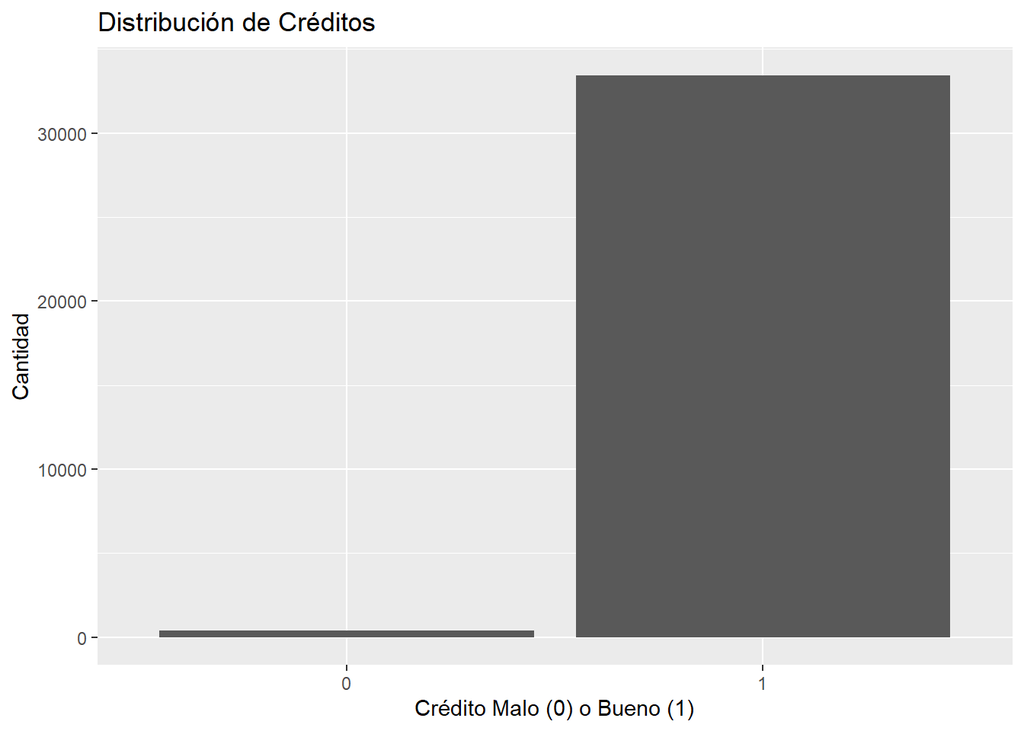

```r
ggplot(dfCreditsReduced) +
  geom_bar(aes(x=Approve)) +
  labs(title="Distribución de Créditos", x="Crédito Malo (0) o Bueno (1)", y="Cantidad")
```

## 3 - Unificar los datasets

### 3.1 - Unificar

```r
dfCreditCard <- merge(dfApplicationsCleaned, dfCreditsReduced, by="ID")
```

### 3.2 - Estructura

```r
str(dfCreditCard)
```

```
## 'data.frame':    24672 obs. of  21 variables:
##  $ ID                 : int  5008804 5008805 5008806 5008808 5008810 5008811 5008813 5008815 5008821 5008824 ...
##  $ CODE_GENDER        : Factor w/ 2 levels "F","M": 2 2 2 1 1 1 1 2 2 2 ...
##  $ FLAG_OWN_CAR       : Factor w/ 2 levels "N","Y": 2 2 2 1 1 1 1 2 2 2 ...
##  $ FLAG_OWN_REALTY    : Factor w/ 2 levels "N","Y": 2 2 2 2 2 2 2 2 2 2 ...
##  $ CNT_CHILDREN       : int  0 0 0 0 0 0 0 0 0 0 ...
##  $ AMT_INCOME_TOTAL   : num  427500 427500 112500 270000 270000 ...
##  $ NAME_INCOME_TYPE   : Factor w/ 5 levels "Commercial associate",..: 5 5 5 1 1 1 2 5 1 1 ...
##  $ NAME_EDUCATION_TYPE: Factor w/ 5 levels "Academic degree",..: 2 2 5 5 5 5 2 2 5 5 ...
##  $ NAME_FAMILY_STATUS : Factor w/ 5 levels "Civil marriage",..: 1 1 2 4 4 4 3 2 2 2 ...
##  $ NAME_HOUSING_TYPE  : Factor w/ 6 levels "Co-op apartment",..: 5 5 2 2 2 2 2 2 2 2 ...
##  $ DAYS_BIRTH         : int  -12005 -12005 -21474 -19110 -19110 -19110 -22464 -16872 -17778 -17778 ...
##  $ DAYS_EMPLOYED      : int  -4542 -4542 -1134 -3051 -3051 -3051 365243 -769 -1194 -1194 ...
##  $ FLAG_MOBIL         : Factor w/ 1 level "1": 1 1 1 1 1 1 1 1 1 1 ...
##  $ FLAG_WORK_PHONE    : Factor w/ 2 levels "0","1": 2 2 1 1 1 1 1 2 1 1 ...
##  $ FLAG_PHONE         : Factor w/ 2 levels "0","1": 1 1 1 2 2 2 1 2 1 1 ...
##  $ FLAG_EMAIL         : Factor w/ 2 levels "0","1": 1 1 1 2 2 2 1 2 1 1 ...
##  $ OCCUPATION_TYPE    : Factor w/ 19 levels "","Accountants",..: 1 1 18 16 16 16 1 2 10 10 ...
##  $ CNT_FAM_MEMBERS    : num  2 2 2 1 1 1 1 2 2 2 ...
##  $ MONTHS_BALANCE     : int  0 0 0 0 0 0 0 0 0 0 ...
##  $ STATUS             : Factor w/ 8 levels "0","1","2","3",..: 7 7 7 1 7 7 1 1 8 1 ...
##  $ Approve            : Factor w/ 2 levels "0","1": 2 2 2 2 2 2 2 2 2 2 ...
```

### 3.3 - Summary

```r
summary(dfCreditCard)
```

```
##        ID          CODE_GENDER FLAG_OWN_CAR FLAG_OWN_REALTY  CNT_CHILDREN
##  Min.   :5008804   F:16406     N:15301      N: 8379         Min.   : 0.0000
##  1st Qu.:5045511   M: 8266     Y: 9371      Y:16293         1st Qu.: 0.0000
##  Median :5069454                                            Median : 0.0000
##  Mean   :5078863                                            Mean   : 0.4175
##  3rd Qu.:5115437                                            3rd Qu.: 1.0000
##  Max.   :5150487                                            Max.   :19.0000
##
##  AMT_INCOME_TOTAL              NAME_INCOME_TYPE
##  Min.   :  27000   Commercial associate: 5849
##  1st Qu.: 121500   Pensioner           : 4150
##  Median : 157500   State servant       : 1953
##  Mean   : 187075   Student             :    9
##  3rd Qu.: 225000   Working             :12711
##  Max.   :1575000
##
##                     NAME_EDUCATION_TYPE            NAME_FAMILY_STATUS
##  Academic degree              :   23    Civil marriage      : 1965
##  Higher education             : 6651    Married             :16942
##  Incomplete higher            :  966    Separated           : 1434
##  Lower secondary              :  250    Single / not married: 3319
##  Secondary / secondary special:16782    Widow               : 1012
##
##
##            NAME_HOUSING_TYPE   DAYS_BIRTH     DAYS_EMPLOYED    FLAG_MOBIL
##  Co-op apartment    :  108   Min.   :-25152   Min.   :-15713   1:24672
##  House / apartment  :22020   1st Qu.:-19453   1st Qu.: -3170
##  Municipal apartment:  785   Median :-15653   Median : -1546
##  Office apartment   :  179   Mean   :-16023   Mean   : 58970
##  Rented apartment   :  374   3rd Qu.:-12542   3rd Qu.:  -401
##  With parents       : 1206   Max.   : -7489   Max.   :365243
##
##  FLAG_WORK_PHONE FLAG_PHONE FLAG_EMAIL    OCCUPATION_TYPE CNT_FAM_MEMBERS
##  0:19049         0:17395    0:22410               :7629   Min.   : 1.000
##  1: 5623         1: 7277    1: 2262    Laborers   :4293   1st Qu.: 2.000
##                                        Core staff :2381   Median : 2.000
##                                        Sales staff:2328   Mean   : 2.184
##                                        Managers   :2008   3rd Qu.: 3.000
##                                        Drivers    :1504   Max.   :20.000
##                                        (Other)    :4529
##  MONTHS_BALANCE     STATUS      Approve
##  Min.   :0      C      :12974   0:  325
##  1st Qu.:0      0      : 6886   1:24347
##  Median :0      X      : 4487
##  Mean   :0      1      :  236
##  3rd Qu.:0      5      :   59
##  Max.   :0      2      :   19
##                 (Other):   11
```

### 3.4 - Conclusiones de la unificación

Luego de unir ambos datasets observamos que la cantidad de registros de clientes que poseen información histórica ha disminuido.

Esto se debe a que no todas las solicitudes de tarjeta de crédito tienen asociado un historial crediticio registrado.

Para los fines de este análisis, aceptaremos cómo válida esta reducción en el set de datos.

```r
print(paste("Registros en el historial:", dim(dfCreditsReduced)[1]))
```

```
## [1] "Registros en el historial: 33856"
```

```r
print(paste("Solicitudes de tarjetas de crédito con registros en el historial:", dim(dfCreditCard)[1]))
```

```
## [1] "Solicitudes de tarjetas de crédito con registros en el historial: 24672"
```

## 4 - Análisis de variables sobre dataset unificado

### 4.1 - Análisis de variables númericas

#### 4.1.1. - Variable: CNT_CHILDREN

##### CNT_CHILDREN

En relación a la variable *CNT_CHILDREN* observaremos la distribución de la cantidad total de hijos en cada barra del siguiente gráfico:

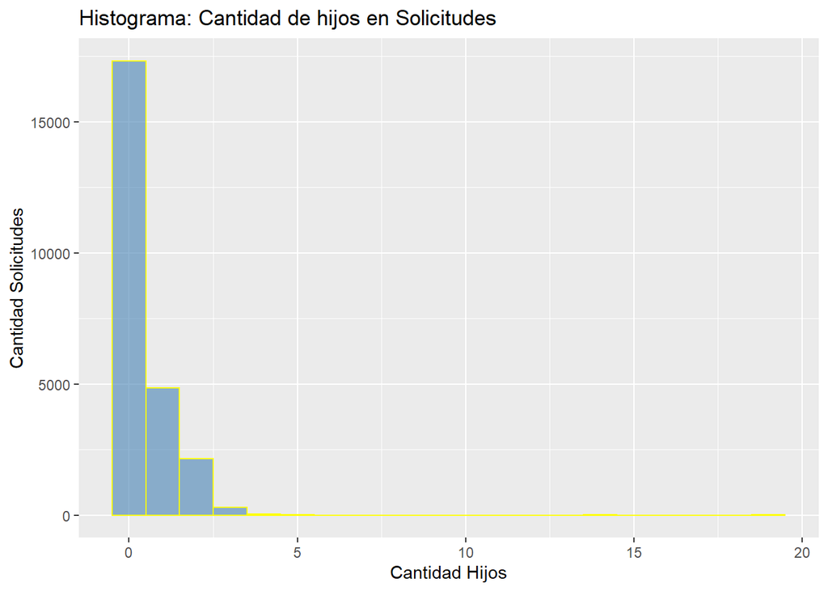

```r
ggplot(dfCreditCard) +
  geom_histogram(
    aes(x=CNT_CHILDREN),
    fill="steel blue",
    col= "yellow",
    alpha= .6,
    binwidth = 1) +
  labs(title="Histograma: Cantidad de hijos en Solicitudes", x="Cantidad Hijos", y="Cantidad Solicitudes")
```

Se observa una marcada concentración respeto de la cantidad de hijos cuando dicho valor es menor o igual a 2.

```r
summary(dfCreditCard$CNT_CHILDREN)
```

```
##    Min. 1st Qu.  Median    Mean 3rd Qu.    Max.
##  0.0000  0.0000  0.0000  0.4175  1.0000 19.0000
```

Se observa en el summary la presencia de valores cercanos a 20, pero como puede observarse en el gráfico anterior son outliers, no hay concentración en esas cantidades.

##### CNT_CHILDREN vs APPROVE

Vamos a utilizar el gráfico BoxPlot para tratar de entender como se relacionan la variable CNT_CHILDREN y nuestra variable Objetivo.

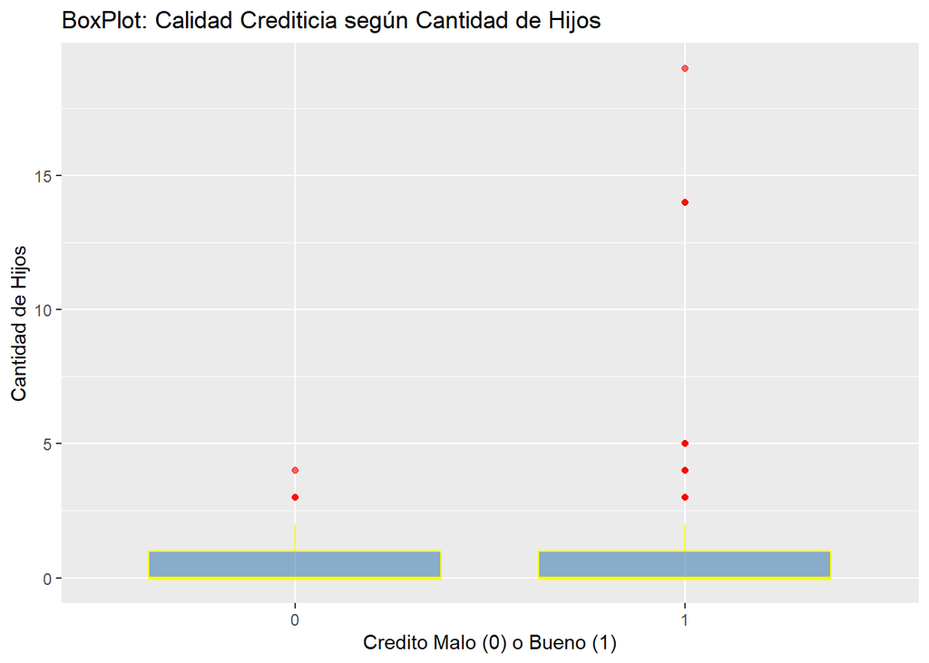

```r
ggplot(dfCreditCard) +
  geom_boxplot(aes(x=Approve, y=CNT_CHILDREN), outlier.color = "red", col="yellow", fill="steel blue", alpha=0.6) +
  labs(title="BoxPlot: Calidad Crediticia según Cantidad de Hijos", x="Credito Malo (0) o Bueno (1)", y="Cantidad de Hijos")
```

Observamos que la cantidad de casos aprobados en comparación de los que no, se mantienen en valores similares.

Vamos a intentar representarlo de manera diferente.

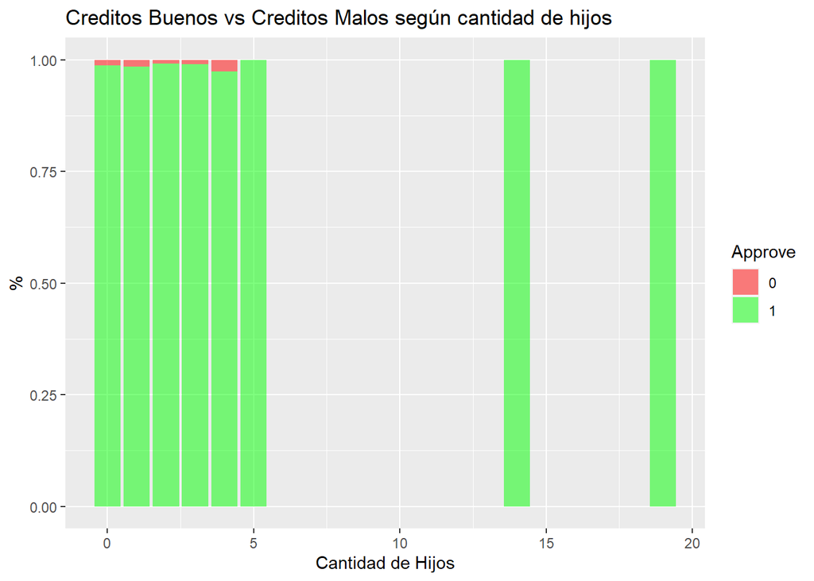

```r
ggplot(dfCreditCard) +
  geom_bar(aes(x=CNT_CHILDREN, fill=Approve), position="fill", alpha=.5) +
  labs(title="Creditos Buenos vs Creditos Malos según cantidad de hijos", x="Cantidad de Hijos", y="%") +
  scale_fill_manual(values= c("0"= "red", "1"="green"))
```

No se observa en el gráfico una relación aparente entre la variable CNT_CHILDREN y la varible objetivo.

#### 4.1.2. - Variable: AMT_INCOME_TOTAL

##### AMT_INCOME_TOTAL

En relación a la variable *AMT_INCOME_TOTAL* observaremos su distribuciónen el siguiente gráfico:

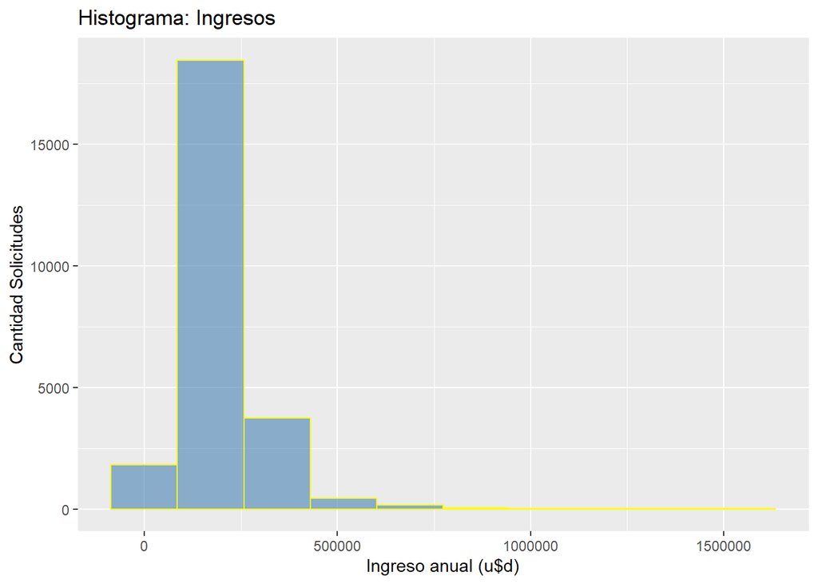

```r
ggplot(dfCreditCard) +
  geom_histogram(
    aes(x=AMT_INCOME_TOTAL),
    fill="steel blue",
    col= "yellow",
    alpha= .6, bins=10) +
  labs(title="Histograma: Ingresos", x="Ingreso anual (u$d)", y="Cantidad Solicitudes")
```

Se observa una marcada concentración de solicitudes en un rango medio de ingresos anuales. si bien se observa la presencia de algunas solicitudes con ingresos muy superiores.

```r
summary(dfCreditCard$AMT_INCOME_TOTAL)
```

```
##    Min. 1st Qu.  Median    Mean 3rd Qu.    Max.
##   27000  121500  157500  187075  225000 1575000
```

Dentro del rango de los 120000 y los 225000 dolares anuales de ingreso se concentra el 50% de las solicitudes de tarjeta de crédito. Vemos la presencia de valores muy inferiores y muy superiores.

##### AMT_INCOME_TOTAL vs APPROVE

Vamos a utilizar el gráfico BoxPlot para tratar de entender como se relacionan la variable AMT_INCOME_TOTAL y nuestra variable Objetivo.

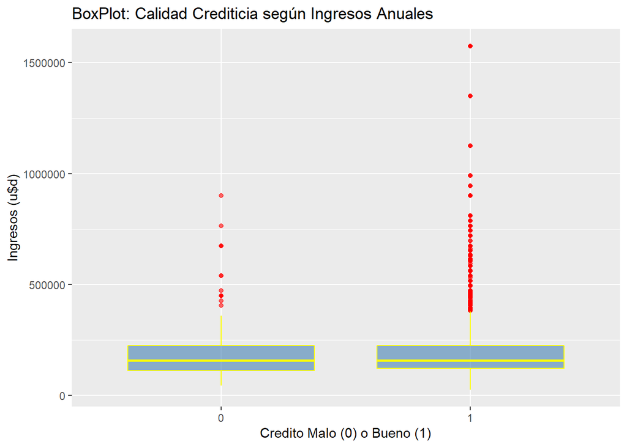

```r
ggplot(dfCreditCard) +
  geom_boxplot(aes(x=Approve, y=AMT_INCOME_TOTAL), outlier.color = "red", col="yellow", fill="steel blue", alpha=0.6) +
  labs(title="BoxPlot: Calidad Crediticia según Ingresos Anuales", x="Credito Malo (0) o Bueno (1)", y="Ingresos (u$d)")
```

No observamos diferencias significativas en este gráfico. Vamos a intentar representarlo de manera diferente.

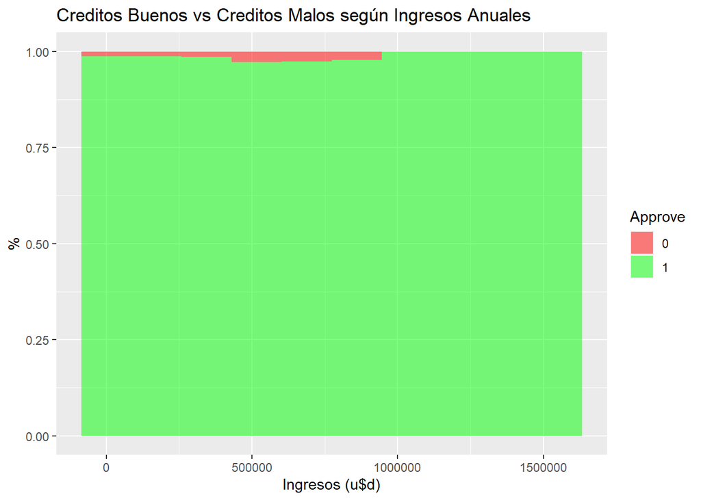

```r
ggplot(dfCreditCard) +
  geom_histogram(aes(x=AMT_INCOME_TOTAL, fill=Approve), position="fill", alpha=.5, bins=10) +
  labs(title="Creditos Buenos vs Creditos Malos según Ingresos Anuales", x="Ingresos (u$d)", y="%") +
  scale_fill_manual(values= c("0"= "red", "1"="green"))
```

Se observa una ligera relación entre las variables. Podría ser un posible predictor.

#### 4.1.3. - Variable: DAYS_BIRTH

##### DAYS_BIRTH

```r
summary(dfCreditCard$DAYS_BIRTH)
```

```
##    Min. 1st Qu.  Median    Mean 3rd Qu.    Max.
##  -25152  -19453  -15653  -16023  -12542   -7489
```

Como se observa, está expresado en días y en negativo, vamos a convertirlo a una escala a la que estamos más acostumbrados a ver, que es expresar la edad en años.

```r
dfCreditCard$AGE <- (dfCreditCard$DAYS_BIRTH * -1) %/% 365
summary(dfCreditCard$AGE)
```

```
##    Min. 1st Qu.  Median    Mean 3rd Qu.    Max.
##   20.00   34.00   42.00   43.39   53.00   68.00
```

Expresado de esta manera podemos observar que los valores son razonables.

Observaremos la distribución en el siguiente gráfico:

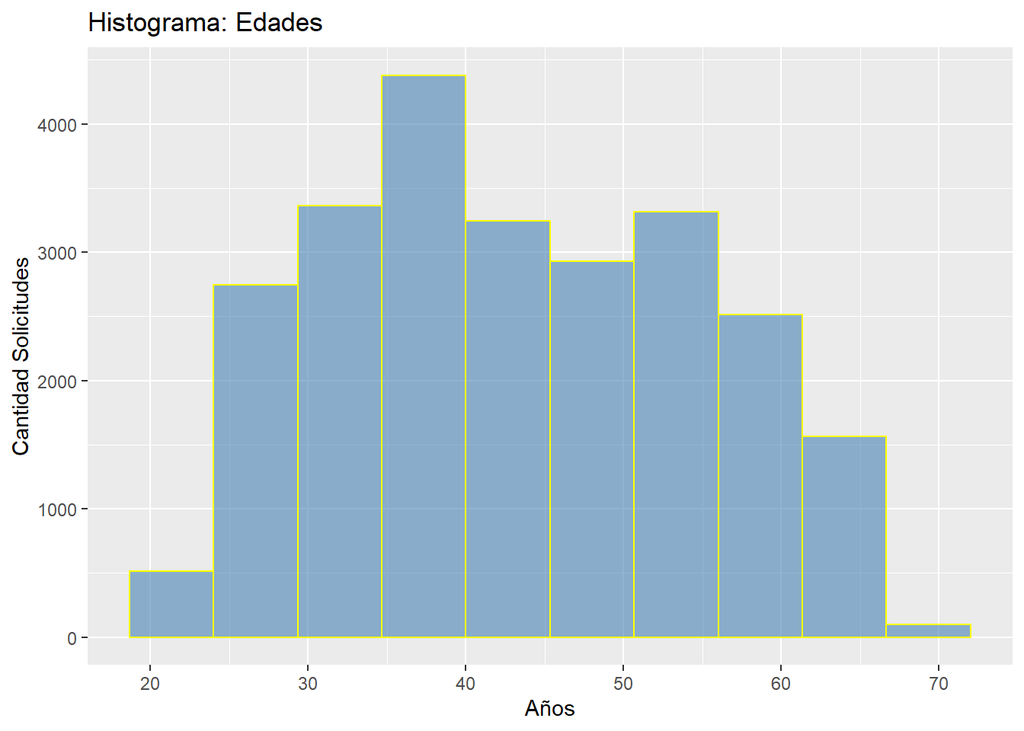

```r
ggplot(dfCreditCard) +
  geom_histogram(
    aes(x=AGE),
    fill="steel blue",
    col= "yellow",
    alpha= .6, bins=10) +
  labs(title="Histograma: Edades", x="Años", y="Cantidad Solicitudes")
```

Observamos una distribución con cierta semejanza a una campana de Gauss (Normal).

##### AGE vs APPROVE

Vamos a utilizar el gráfico BoxPlot para tratar de entender como se relacionan la variable AGE y nuestra variable Objetivo.

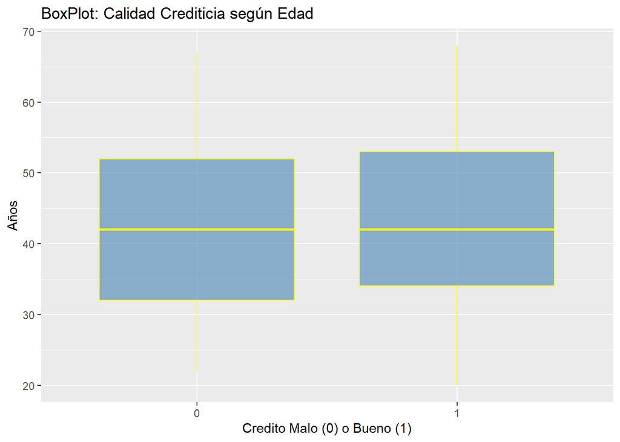

```r
ggplot(dfCreditCard) +
  geom_boxplot(aes(x=Approve, y=AGE), outlier.color = "red", col="yellow", fill="steel blue", alpha=0.6) +
  labs(title="BoxPlot: Calidad Crediticia según Edad", x="Credito Malo (0) o Bueno (1)", y="Años")
```

Se observa alguna leve tendencia. Vamos a intentar representarlo de manera diferente.

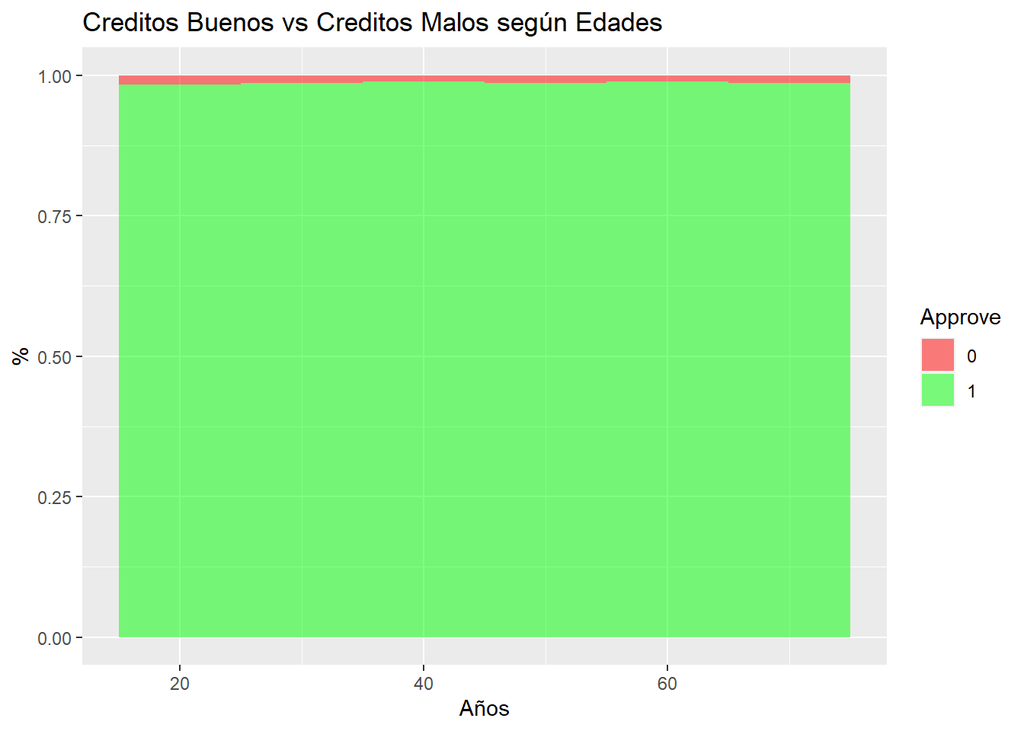

```r
ggplot(dfCreditCard) +
  geom_histogram(aes(x=AGE, fill=Approve), position="fill", alpha=.5, binwidth = 10) +
  labs(title="Creditos Buenos vs Creditos Malos según Edades", x="Años", y="%") +
  scale_fill_manual(values= c("0"= "red", "1"="green"))
```

#### 4.1.4. - Variable: DAYS_EMPLOYED

##### DAYS_EMPLOYED

```r
summary(dfCreditCard$DAYS_EMPLOYED)
```

```
##    Min. 1st Qu.  Median    Mean 3rd Qu.    Max.
##  -15713   -3170   -1546   58970    -401  365243
```

Como se observa, está expresado en días y en negativo, vamos a convertirlo a una escala a la que estamos más acostumbrados a ver, que es expresarlo en años. Se observan también valores positivos, que se les va a tener que dar un tratamiento.

```r
dfCreditCard$YEARS_EMPLOYED <- (dfCreditCard$DAYS_EMPLOYED * -1) %/% 365
summary(dfCreditCard$YEARS_EMPLOYED)
```

```
##    Min. 1st Qu.  Median    Mean 3rd Qu.    Max.
##   -1001       1       4    -162       8      43
```

Expresado de esta manera podemos observar edades negativas.

Buscamos estos valores:

```r
dfNegatives <- filter(dfCreditCard, YEARS_EMPLOYED < 0)
str(dfNegatives)
```

```
## 'data.frame':    4133 obs. of  23 variables:
##  $ ID                 : int  5008813 5008827 5008884 5008976 5008977 5008979 5009033 5009035 5009036 5009037 ...
##  $ CODE_GENDER        : Factor w/ 2 levels "F","M": 1 2 1 1 1 1 1 1 1 1 ...
##  $ FLAG_OWN_CAR       : Factor w/ 2 levels "N","Y": 1 2 1 1 1 1 1 1 1 1 ...
##  $ FLAG_OWN_REALTY    : Factor w/ 2 levels "N","Y": 2 2 2 2 2 2 1 1 1 1 ...
##  $ CNT_CHILDREN       : int  0 0 0 0 0 0 0 0 0 0 ...
##  $ AMT_INCOME_TOTAL   : num  283500 180000 315000 112500 112500 ...
##  $ NAME_INCOME_TYPE   : Factor w/ 5 levels "Commercial associate",..: 2 2 2 2 2 2 2 2 2 2 ...
##  $ NAME_EDUCATION_TYPE: Factor w/ 5 levels "Academic degree",..: 2 2 5 5 5 5 3 3 3 3 ...
##  $ NAME_FAMILY_STATUS : Factor w/ 5 levels "Civil marriage",..: 3 2 5 2 2 2 1 1 1 1 ...
##  $ NAME_HOUSING_TYPE  : Factor w/ 6 levels "Co-op apartment",..: 2 2 2 2 2 2 5 5 5 5 ...
##  $ DAYS_BIRTH         : int  -22464 -18772 -20186 -22319 -22319 -22319 -18682 -18682 -18682 -18682 ...
##  $ DAYS_EMPLOYED      : int  365243 365243 365243 365243 365243 365243 365243 365243 365243 365243 ...
##  $ FLAG_MOBIL         : Factor w/ 1 level "1": 1 1 1 1 1 1 1 1 1 1 ...
##  $ FLAG_WORK_PHONE    : Factor w/ 2 levels "0","1": 1 1 1 1 1 1 1 1 1 1 ...
##  $ FLAG_PHONE         : Factor w/ 2 levels "0","1": 1 1 1 1 1 1 1 1 1 1 ...
##  $ FLAG_EMAIL         : Factor w/ 2 levels "0","1": 1 1 1 1 1 1 1 1 1 1 ...
##  $ OCCUPATION_TYPE    : Factor w/ 19 levels "","Accountants",..: 1 1 1 1 1 1 1 1 1 1 ...
##  $ CNT_FAM_MEMBERS    : num  1 2 1 2 2 2 2 2 2 2 ...
##  $ MONTHS_BALANCE     : int  0 0 0 0 0 0 0 0 0 0 ...
##  $ STATUS             : Factor w/ 8 levels "0","1","2","3",..: 1 7 7 1 1 7 8 8 7 8 ...
##  $ Approve            : Factor w/ 2 levels "0","1": 2 2 2 2 2 2 2 2 2 2 ...
##  $ AGE                : num  61 51 55 61 61 61 51 51 51 51 ...
##  $ YEARS_EMPLOYED     : num  -1001 -1001 -1001 -1001 -1001 ...
```

Observamos un número importante de registros con valores negativos (inválidos). Cómo no podemos consultar a negocio que significan estos valores decidimos interpretarlos cómo “antigüedad laboral desconocida”, los vamos a reemplazar por la mediana, que es más representativa de la antigüedad que el promedio, justamente por la presencia de estos valores.

```r
dfCreditCard$YEARS_EMPLOYED[dfCreditCard$YEARS_EMPLOYED < 0] <- median(dfCreditCard$YEARS_EMPLOYED)

summary(dfCreditCard$YEARS_EMPLOYED)
```

```
##    Min. 1st Qu.  Median    Mean 3rd Qu.    Max.
##   0.000   3.000   4.000   6.321   8.000  43.000
```

Ahora los valores parecen razonables.

Observaremos la distribución en el siguiente gráfico:

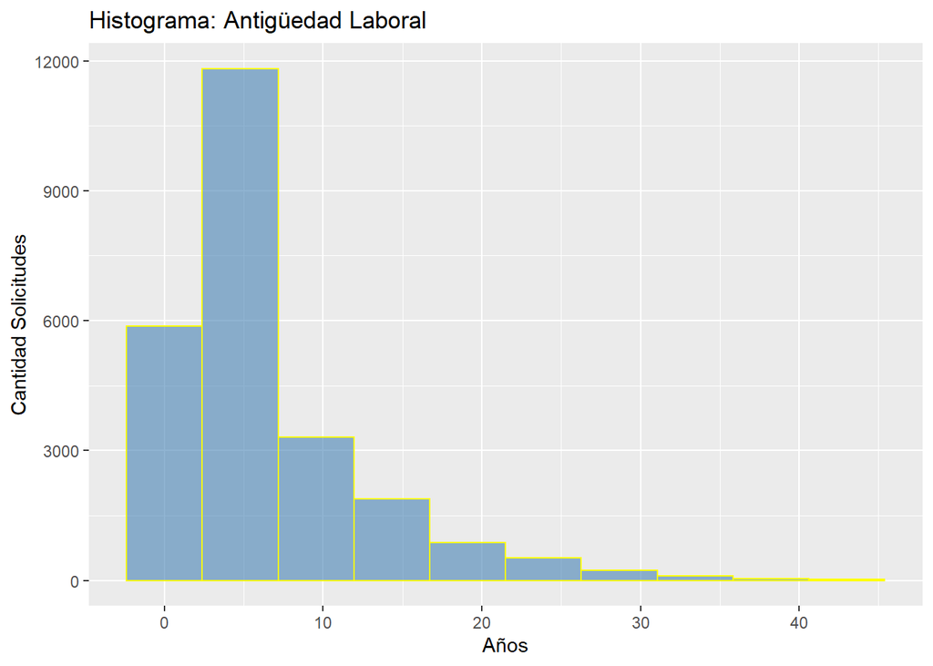

```r
ggplot(dfCreditCard) +
  geom_histogram(
    aes(x=YEARS_EMPLOYED),
    fill="steel blue",
    col= "yellow",
    alpha= .6, bins=10) +
  labs(title="Histograma: Antigüedad Laboral", x="Años", y="Cantidad Solicitudes")
```

##### YEARS_EMPLOYED vs APPROVE

Vamos a utilizar el gráfico BoxPlot para tratar de entender como se relacionan la variable YEARS_EMPLOYED y nuestra variable Objetivo.

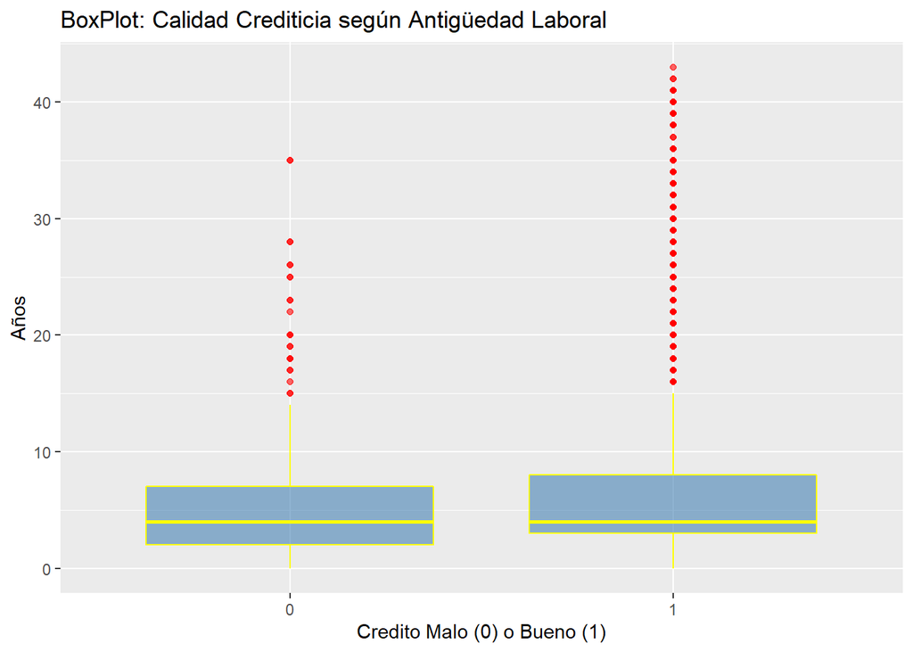

```r
ggplot(dfCreditCard) +
  geom_boxplot(aes(x=Approve, y=YEARS_EMPLOYED), outlier.color = "red", col="yellow", fill="steel blue", alpha=0.6) +
  labs(title="BoxPlot: Calidad Crediticia según Antigüedad Laboral", x="Credito Malo (0) o Bueno (1)", y="Años")
```

Se observan algunas leves diferencias en este gráfico. Vamos a intentar representarlo de manera diferente.

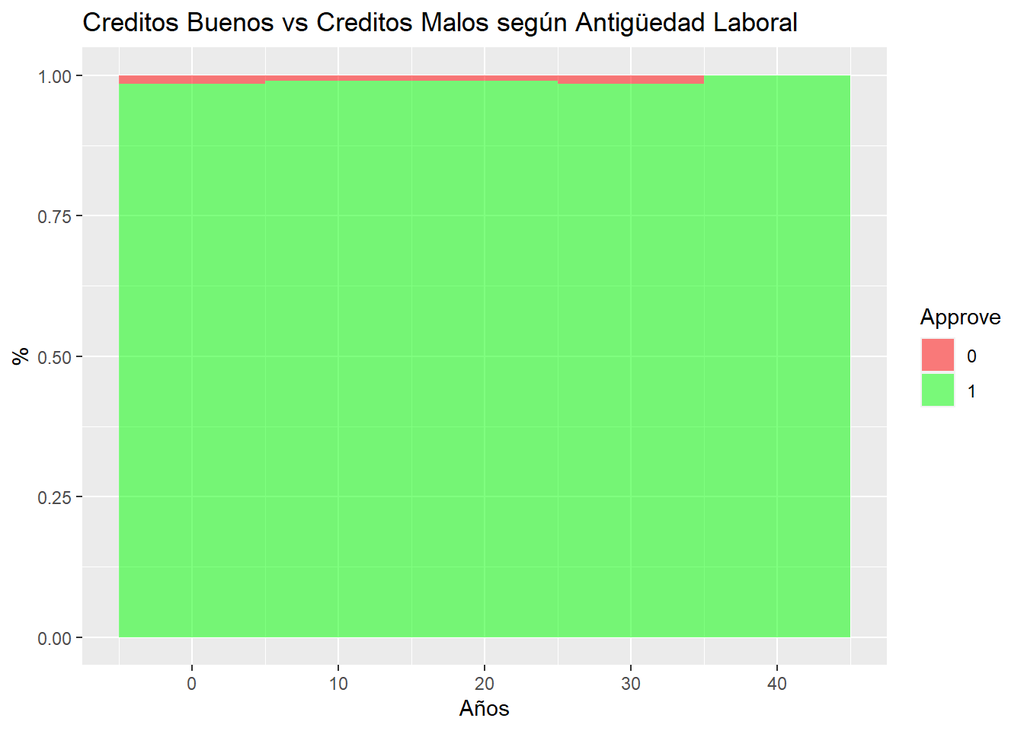

```r
ggplot(dfCreditCard) +
  geom_histogram(aes(x=YEARS_EMPLOYED, fill=Approve), position="fill", alpha=.5, binwidth = 10) +
  labs(title="Creditos Buenos vs Creditos Malos según Antigüedad Laboral", x="Años", y="%") +
  scale_fill_manual(values= c("0"= "red", "1"="green"))
```

La leve diferencia notada en el gráfico anterior se mantiene, podría ser un posible predictor.

#### 4.1.5. - Variable: CNT_FAM_MEMBERS

##### CNT_FAM_MEMBERS

En relación a la variable *CNT_FAM_MEMBERS* observaremos la distribución de la cantidad total de integrantes de la familia, en cada barra del siguiente gráfico:

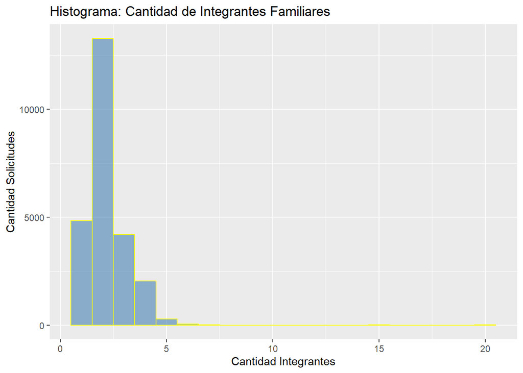

```r
ggplot(dfCreditCard) +
  geom_histogram(
    aes(x=CNT_FAM_MEMBERS),
    fill="steel blue",
    col= "yellow",
    alpha= .6,
    binwidth = 1) +
  labs(title="Histograma: Cantidad de Integrantes Familiares", x="Cantidad Integrantes", y="Cantidad Solicitudes")
```

Como era de esperarse se observa una distribución similar a la cantidad de hijos, son variables claramente relacionadas.

##### CNT_FAM_MEMBERS vs APPROVE

Es de esperarse que la relación entre estas dos variables sea similar a lo ya evaluado con cantidad de hijos, se utiliza el gráfico de barras para convalidarlo.

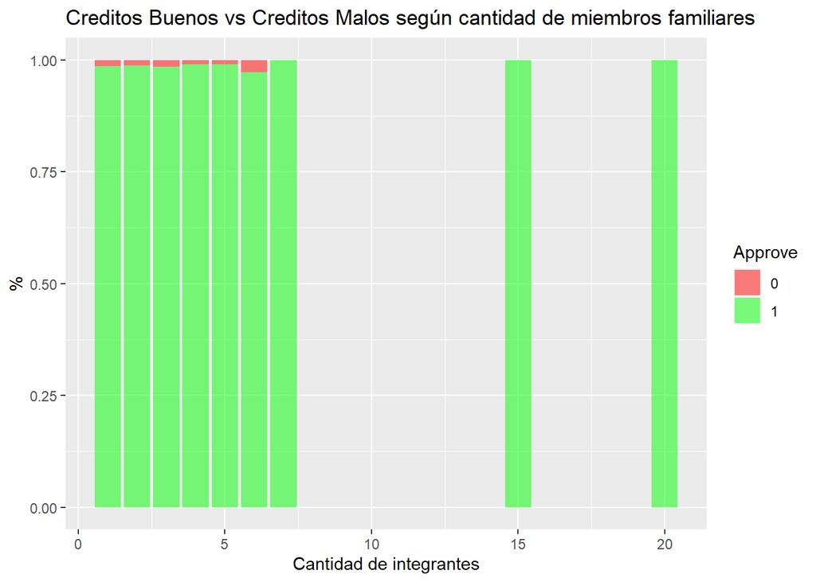

```r
ggplot(dfCreditCard) +
  geom_bar(aes(x=CNT_FAM_MEMBERS, fill=Approve), position="fill", alpha=.5) +
  labs(title="Creditos Buenos vs Creditos Malos según cantidad de miembros familiares", x="Cantidad de integrantes", y="%") +
  scale_fill_manual(values= c("0"= "red", "1"="green"))
```

No se verifica una tendencia que justifique incluirlo como predictor.

### 4.2 - Correlación de variables numéricas

Mediante un gráfico de correlación de las variables numéricas vamos a analizar como se relacionan entre ellas.

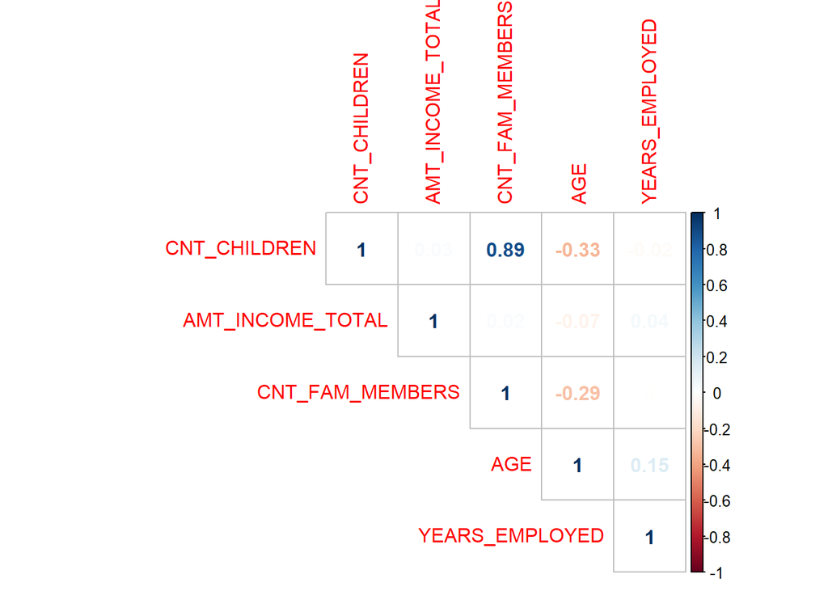

```r
dfcor <- select_if(dfCreditCard, is.numeric)
dfcor <- select(dfcor, -ID, -MONTHS_BALANCE, -DAYS_EMPLOYED, -DAYS_BIRTH)
cm <- cor(dfcor)
corrplot(cm, method = "number", type = "upper")
```

Observamos en el gráfico que Cantidad de Hijos y Cantidad de Miembros Familiares están muy relaionados, nos parece más amplio el concepto de Miembros Familiares si hubiera que seleccionarlo como predictor.

No observamos correlaciones significativas entre el resto de las variables.

### 4.3 - Análisis de variables categóricas

#### 4.3.1 - Variable: CODE_GENDER

##### CODE_GENDER

Para conocere la distribución de la muestra graficamos con barras las 2 categorías:

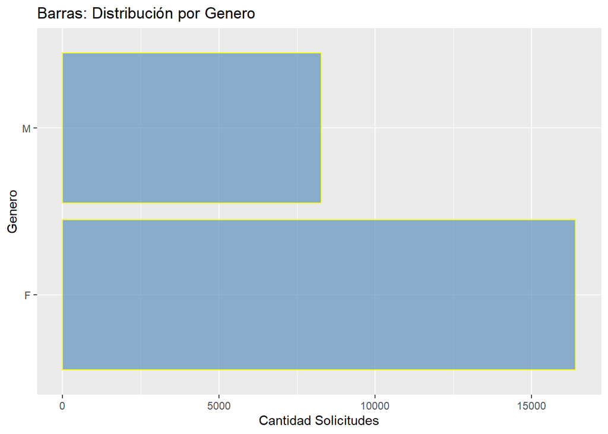

```r
ggplot(dfCreditCard) +
  geom_bar(
    aes(x=CODE_GENDER),
    stat="count",
    fill="steel blue",
    col= "yellow",
    alpha= .6) +
    labs(title="Barras: Distribución por Genero", x="Genero", y="Cantidad Solicitudes") +
    coord_flip()
```

Se observa que la muestra contiene aproximadamente el doble de mujeres. Evaluar si es algo que podría sesgar el modelo.

##### CODE_GENDER vs APPROVE

Verificamos si podría existir alguna relación entre ambas variables mediante un gráfico de barras apiladas.

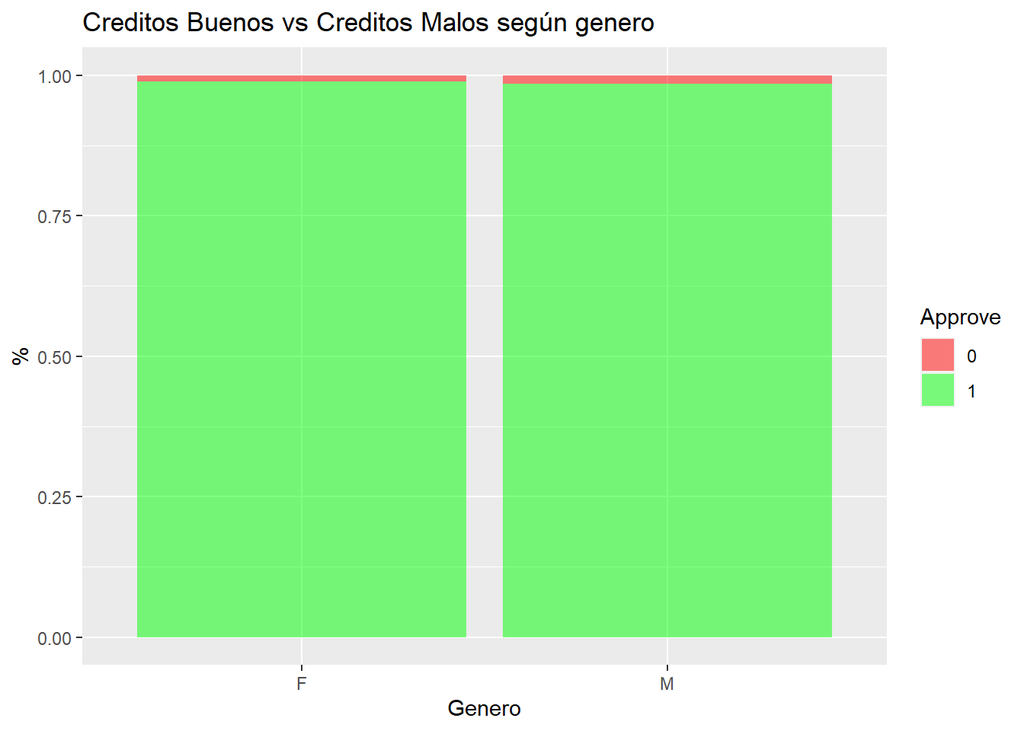

```r
ggplot(dfCreditCard) +
  geom_bar(aes(x=CODE_GENDER, fill=Approve), position="fill", alpha=.5) +
  labs(title="Creditos Buenos vs Creditos Malos según genero", x="Genero", y="%") +
  scale_fill_manual(values= c("0"= "red", "1"="green"))
```

A pesar que la muestra contenía mayor cantidad de solicitudes del sexo femenino, la distribución respecto a la calidad crediticia es similar a las solicitudes presentadas por el sexo masculino. No parece existir una relación entre el genero y la calidad crediticia.

#### 4.3.2 - Variable: FLAG_OWN_CAR

##### FLAG_OWN_CAR

Para conocere la distribución de la muestra graficamos con barras las 2 categorías:

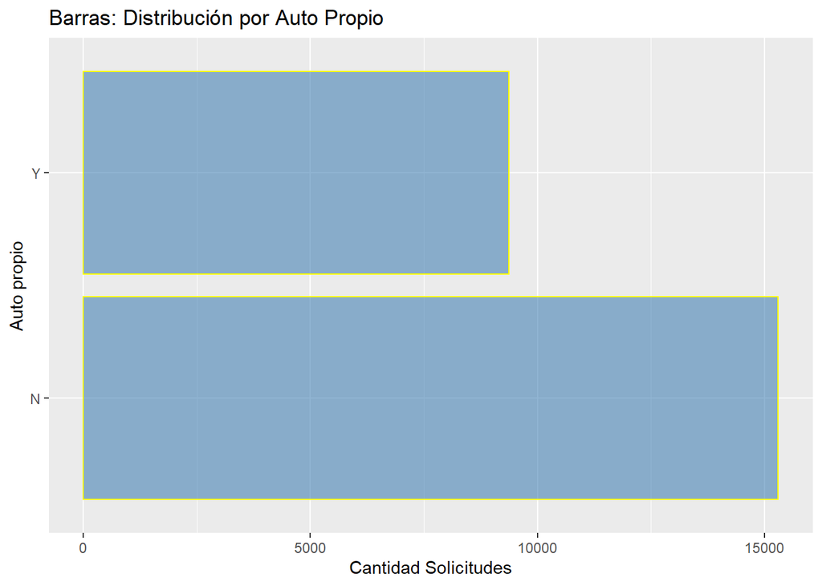

```r
ggplot(dfCreditCard) +
  geom_bar(
    aes(x=FLAG_OWN_CAR),
    stat="count",
    fill="steel blue",
    col= "yellow",
    alpha= .6) +
    labs(title="Barras: Distribución por Auto Propio", x="Auto propio", y="Cantidad Solicitudes") +
    coord_flip()
```

##### FLAG_OWN_CAR vs APPROVE

Verificamos si podría existir alguna relación entre ambas variables mediante un gráfico de barras apiladas.

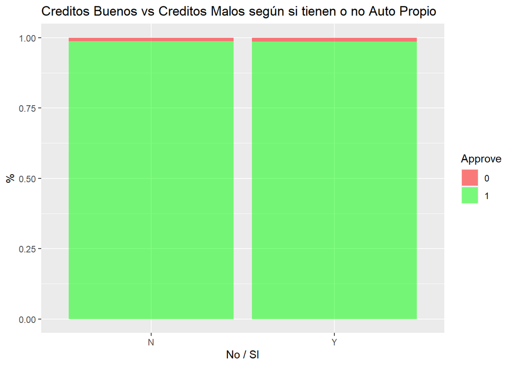

```r
ggplot(dfCreditCard) +
  geom_bar(aes(x=FLAG_OWN_CAR, fill=Approve), position="fill", alpha=.5) +
  labs(title="Creditos Buenos vs Creditos Malos según si tienen o no Auto Propio", x="No / SI", y="%") +
  scale_fill_manual(values= c("0"= "red", "1"="green"))
```

No parece existir una relación entre el Auto Propio y la calidad crediticia.

#### 4.3.3 - Variable: FLAG_OWN_REALTY

##### FLAG_OWN_REALTY

Para conocere la distribución de la muestra graficamos con barras las 2 categorías:

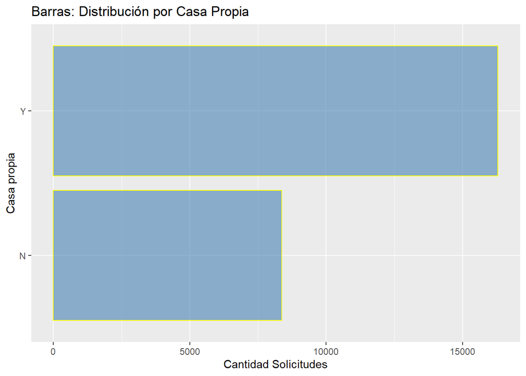

```r
ggplot(dfCreditCard) +
  geom_bar(
    aes(x=FLAG_OWN_REALTY),
    stat="count",
    fill="steel blue",
    col= "yellow",
    alpha= .6) +
    labs(title="Barras: Distribución por Casa Propia", x="Casa propia", y="Cantidad Solicitudes") +
    coord_flip()
```

##### FLAG_OWN_REALTY vs APPROVE

Verificamos si podría existir alguna relación entre ambas variables mediante un gráfico de barras apiladas.

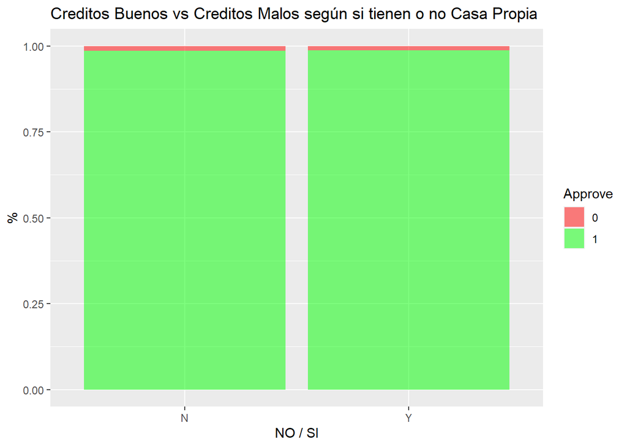

```r
ggplot(dfCreditCard) +
  geom_bar(aes(x=FLAG_OWN_REALTY, fill=Approve), position="fill", alpha=.5) +
  labs(title="Creditos Buenos vs Creditos Malos según si tienen o no Casa Propia", x="NO / SI", y="%") +
  scale_fill_manual(values= c("0"= "red", "1"="green"))
```

Parecería existir alguna tendencia a favor de los que poseen casa propia, podría ser un posible predictor.

#### 4.3.4 - Variable: FLAG_MOBIL

##### FLAG_MOBIL

Para conocere la distribución de la muestra graficamos con barras las 2 categorías:

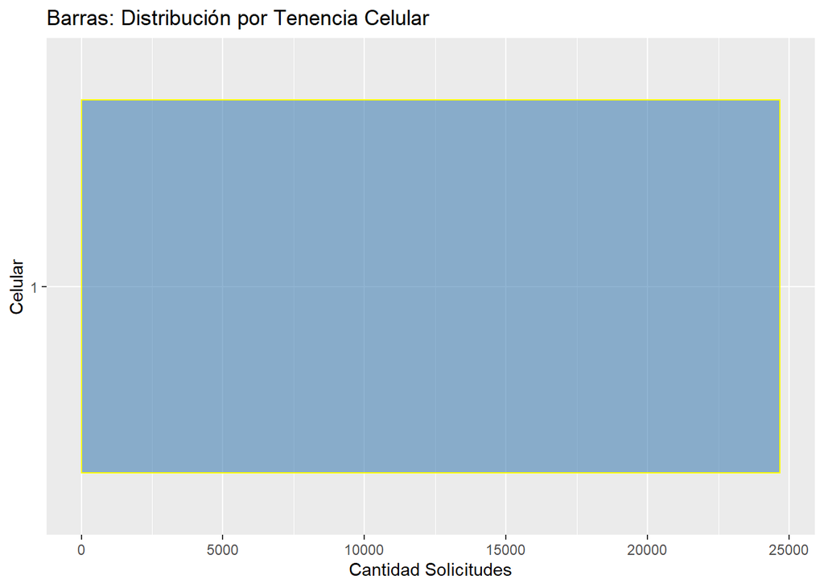

```r
ggplot(dfCreditCard) +
  geom_bar(
    aes(x=FLAG_MOBIL),
    stat="count",
    fill="steel blue",
    col= "yellow",
    alpha= .6) +
    labs(title="Barras: Distribución por Tenencia Celular", x="Celular", y="Cantidad Solicitudes") +
    coord_flip()
```

Como ya habíamos mencionado anteriormente, se observa que todos las solicitudes tienen Teléfono Celular, no nos sirve para la predicción.

#### 4.3.5 - Variable: FLAG_WORK_PHONE

##### FLAG_WORK_PHONE

Para conocere la distribución de la muestra graficamos con barras las 2 categorías:

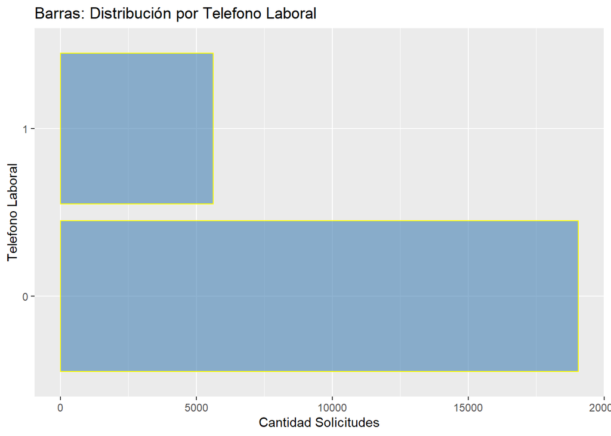

```r
ggplot(dfCreditCard) +
  geom_bar(
    aes(x=FLAG_WORK_PHONE),
    stat="count",
    fill="steel blue",
    col= "yellow",
    alpha= .6) +
    labs(title="Barras: Distribución por Telefono Laboral", x="Telefono Laboral", y="Cantidad Solicitudes") +
    coord_flip()
```

##### FLAG_WORK_PHONE vs APPROVE

Verificamos si podría existir alguna relación entre ambas variables mediante un gráfico de barras apiladas.

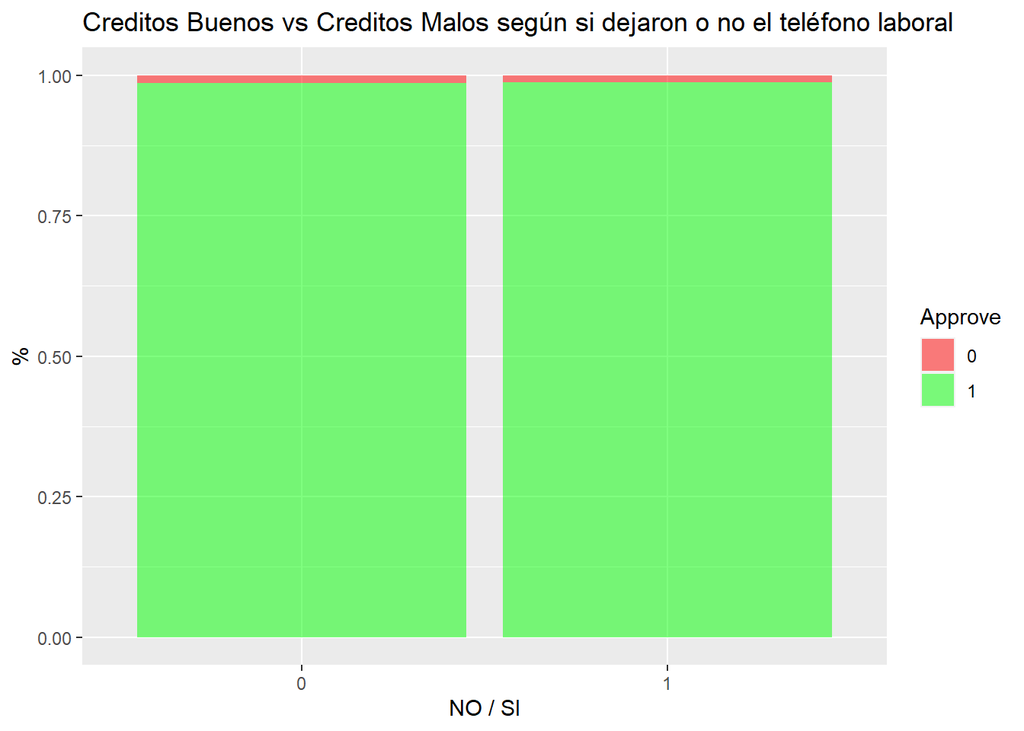

```r
ggplot(dfCreditCard) +
  geom_bar(aes(x=FLAG_WORK_PHONE, fill=Approve), position="fill", alpha=.5) +
  labs(title="Creditos Buenos vs Creditos Malos según si dejaron o no el teléfono laboral", x="NO / SI", y="%") +
  scale_fill_manual(values= c("0"= "red", "1"="green"))
```

Parece existir una ligera diferencia, podría ser un posible predictor.

#### 4.3.6 - Variable: FLAG_PHONE

##### FLAG_PHONE

Para conocere la distribución de la muestra graficamos con barras las 2 categorías:

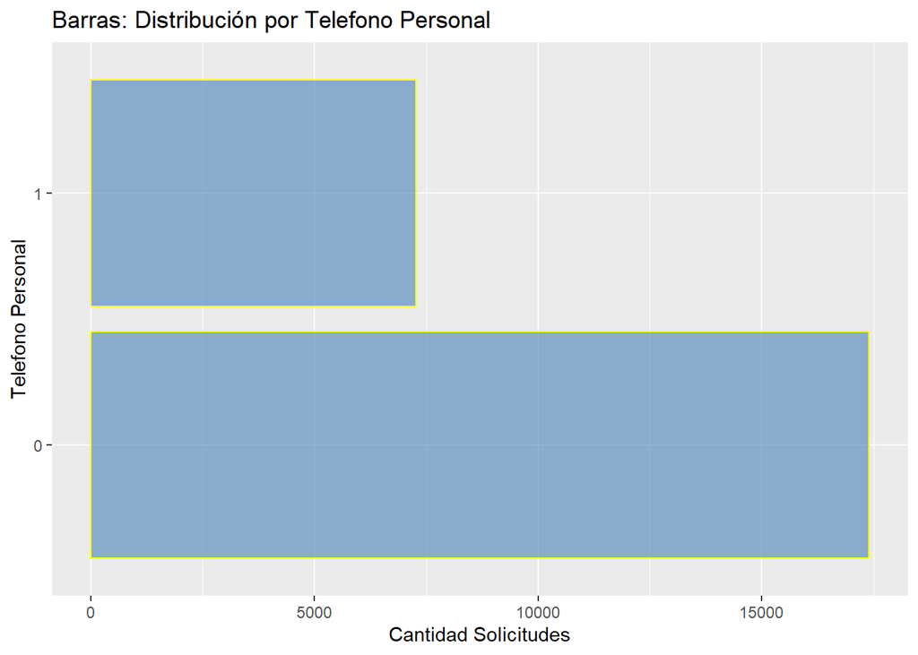

```r
ggplot(dfCreditCard) +
  geom_bar(
    aes(x=FLAG_PHONE),
    stat="count",
    fill="steel blue",
    col= "yellow",
    alpha= .6) +
    labs(title="Barras: Distribución por Telefono Personal", x="Telefono Personal", y="Cantidad Solicitudes") +
    coord_flip()
```

##### FLAG_PHONE vs APPROVE

Verificamos si podría existir alguna relación entre ambas variables mediante un gráfico de barras apiladas.

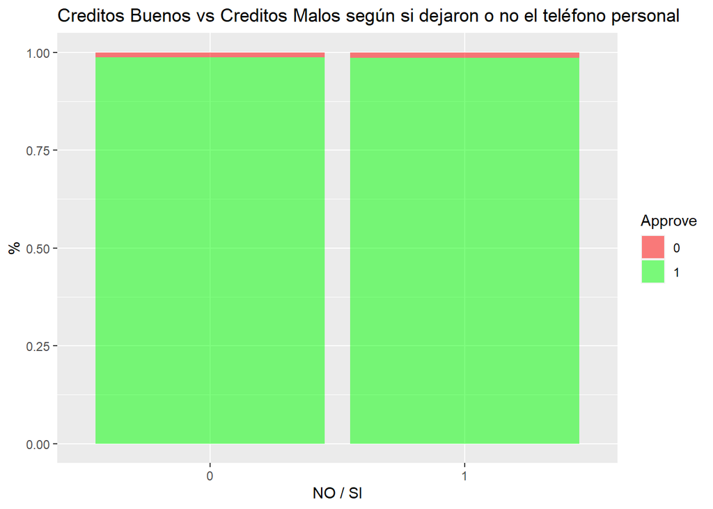

```r
ggplot(dfCreditCard) +
  geom_bar(aes(x=FLAG_PHONE, fill=Approve), position="fill", alpha=.5) +
  labs(title="Creditos Buenos vs Creditos Malos según si dejaron o no el teléfono personal", x="NO / SI", y="%") +
  scale_fill_manual(values= c("0"= "red", "1"="green"))
```

No parece existir una relación entre el teléfono personal y la calidad crediticia.

#### 4.3.7 - Variable: FLAG_EMAIL

##### FLAG_EMAIL

Para conocere la distribución de la muestra graficamos con barras las 2 categorías:

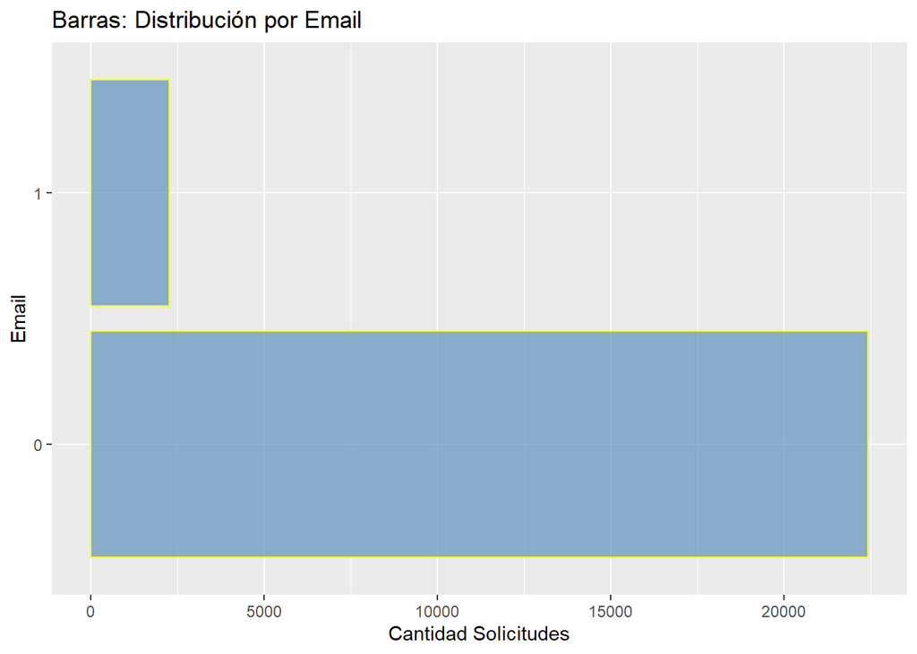

```r
ggplot(dfCreditCard) +
  geom_bar(
    aes(x=FLAG_EMAIL),
    stat="count",
    fill="steel blue",
    col= "yellow",
    alpha= .6) +
    labs(title="Barras: Distribución por Email", x="Email", y="Cantidad Solicitudes") +
    coord_flip()
```

##### FLAG_EMAIL vs APPROVE

Verificamos si podría existir alguna relación entre ambas variables mediante un gráfico de barras apiladas.

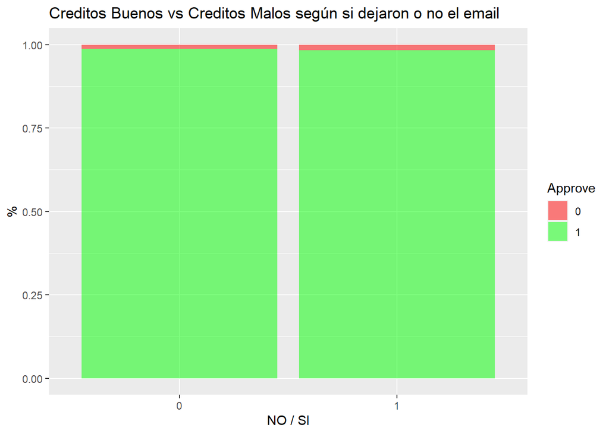

```r
ggplot(dfCreditCard) +
  geom_bar(aes(x=FLAG_EMAIL, fill=Approve), position="fill", alpha=.5) +
  labs(title="Creditos Buenos vs Creditos Malos según si dejaron o no el email", x="NO / SI", y="%") +
  scale_fill_manual(values= c("0"= "red", "1"="green"))
```

Parece existir una muy ligera diferencia, podría ser un posible predictor.

#### 4.3.8 - Variable: NAME_INCOME_TYPE

##### NAME_INCOME_TYPE

En esta variable se observó una categoría *student* muy poco representada, sin casos negativos, que va a generar ruido en el modelo predictivo. A los fines del análisis se decidió reemplazarlos por la categoría mas representativa *working*

```r
dfCreditCard$NAME_INCOME_TYPE[dfCreditCard$NAME_INCOME_TYPE == "Student"] <- "Working"
dfCreditCard$NAME_INCOME_TYPE <- factor(dfCreditCard$NAME_INCOME_TYPE)
```

Para conocere la distribución de la muestra graficamos con barras diferentes categorías:

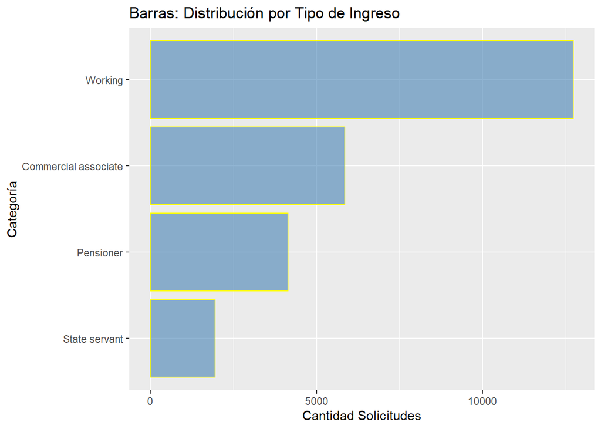

```r
catIncomeType <- table(dfCreditCard$NAME_INCOME_TYPE)
dfCatIncomeType <- as.data.frame(catIncomeType)
names(dfCatIncomeType) <- c("Categoria","Cantidad")

# Ordenamos
dfCatIncomeType <- transform(dfCatIncomeType, Categoria=reorder(Categoria, Cantidad))

ggplot(dfCatIncomeType) +
  geom_bar(
    aes(x=Categoria, y=Cantidad),
    stat="identity",
    fill="steel blue",
    col= "yellow",
    alpha= .6) +
    labs(title="Barras: Distribución por Tipo de Ingreso", x="Categoría", y="Cantidad Solicitudes") +
    coord_flip()
```

##### NAME_INCOME_TYPE vs APPROVE

Verificamos si podría existir alguna relación entre ambas variables mediante un gráfico de barras apiladas.

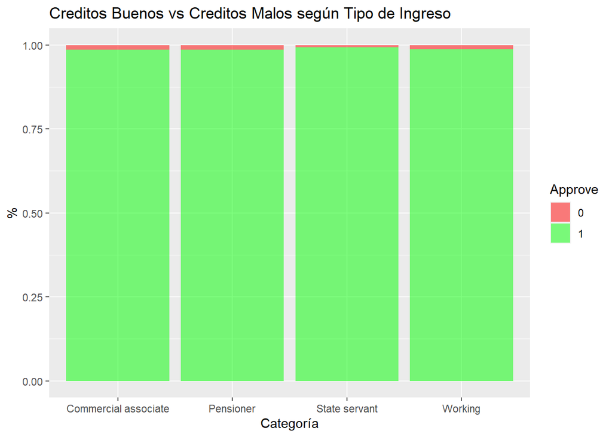

```r
ggplot(dfCreditCard) +
  geom_bar(aes(x=NAME_INCOME_TYPE, fill=Approve), position="fill", alpha=.5) +
  labs(title="Creditos Buenos vs Creditos Malos según Tipo de Ingreso", x="Categoría", y="%") +
  scale_fill_manual(values= c("0"= "red", "1"="green"))
```